# hw6_lm_FHChang

Feng-Hsun Chang

2016.Oct.17

First I read in data from my own GitHub repository

```r
library(RCurl)
library(plyr)
library(dplyr)
library(tidyr)
library(ggplot2)
library(gridExtra)
library(lmtest)

dat1_raw=read.csv(text=getURL("https://raw.githubusercontent.com/OscarFHC/EEB480_ModelInfer_assignment/master/Mod_Infer_hw6/Parus_major_Wytham_Wood.csv"), sep=",", header=T,comment.char="#")
dat2_raw=read.csv(text=getURL("https://raw.githubusercontent.com/OscarFHC/EEB480_ModelInfer_assignment/master/Mod_Infer_hw6/Thrips_imaginis_Davidson1948.csv"), sep=",", header=T,comment.char="#")
parus = dat1_raw %>%
  rename(yr=Sample.Date, pop.nat=Population)
thrip = dat2_raw %>%
  mutate(yr=Sample.Date%/%1,
         month=round(100*(Sample.Date%%1)),
         time=yr+month/12,
         pop.nat=Population,
         Population=NULL,
         Sample.Date=NULL)
```

# Exercise 1

Here I plot the time series of each data set in untransformed population size (pop.nat), squared root-transformed population size (pop.sqrt) and log-transformed population size (pop.log).

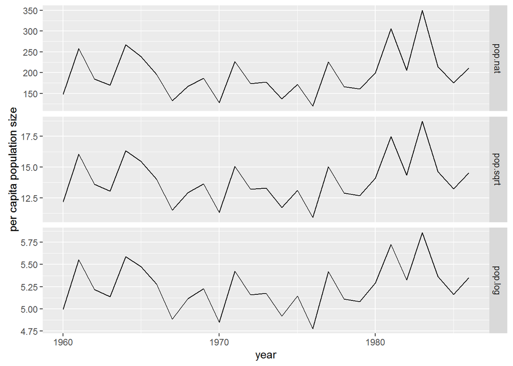

```r
parus.ex1 = parus %>%
  mutate(pop.sqrt=sqrt(pop.nat), pop.log=log(pop.nat)) %>%
  gather(key=variable, value=pop, -c(yr))
parus.ex1[,"variable"]=factor(parus.ex1[,"variable"], levels=c("pop.nat", "pop.sqrt", "pop.log"))

ggplot(data=parus.ex1, aes(x=yr, y=pop), group=gp)+
  geom_line()+
  facet_grid(variable ~ ., scales = "free_y")+
  xlab("year")+
  ylab("per capita population size")
```

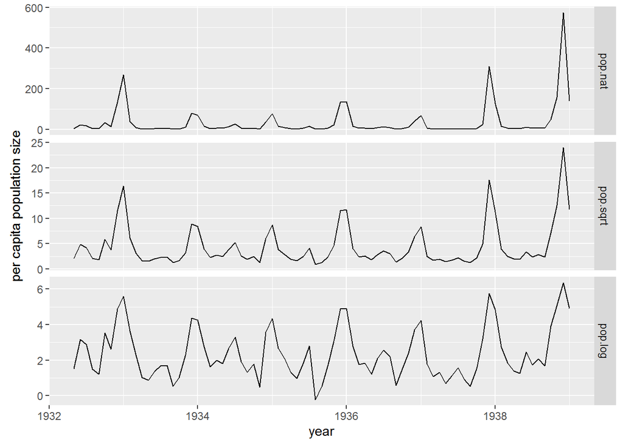

```r
thrip.ex1 = thrip %>%
  mutate(pop.sqrt=sqrt(pop.nat), pop.log=log(pop.nat)) %>%
  gather(key=variable, value=pop, -c(yr, month, time))
thrip.ex1[,"variable"]=factor(thrip.ex1[,"variable"], levels=c("pop.nat", "pop.sqrt", "pop.log"))

ggplot(data=thrip.ex1, aes(x=time, y=pop), group=variable)+
  geom_line()+
  facet_grid(variable ~ ., scales = "free_y")+
  xlab("year")+
  ylab("per capita population size")
```

```r
  # Question: not sure how to organize the format of date? Like what should I do if I want to make the label of x=axis as 1934 Mar., etc
```

Here I found that, among the three transformations of the population size, the dynamics of parus population (the first figure) are more similar than those of thrip population. This is probably due to the fact the parus population size is more normally distributed (the parus population is almost normally distributed, p-value of Shapiro-Wilk normality test is 0.0536849), but the thrip population size distribution is highly right skewed.

# Exercise 2

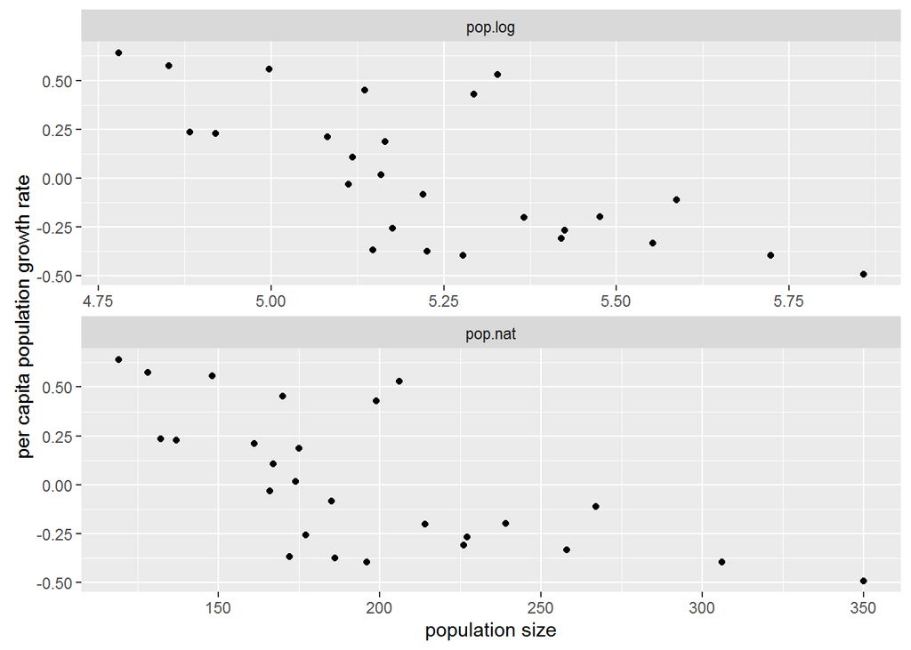

```r
parus.ex2 = parus  %>%
  mutate(pop.log=log(pop.nat)) %>%
  mutate(ratio=c(log(parus[,"pop.nat"][2:nrow(parus)]/parus[,"pop.nat"][1:(nrow(parus)-1)]), "NA")) %>%
  filter(ratio!="NA") %>%
  gather(key=variable, value=pop, -c(yr, ratio))

ggplot(data=parus.ex2, aes(x=pop, y=as.numeric(ratio)), group=variable)+
  geom_point()+
  facet_wrap(~variable, nrow=2, scales="free")+
  #facet_grid(variable~., scales = "free")+ #this is not working
  xlab("population size")+
  ylab("per capita population growth rate")
```

The parus data set returns me similar patterns and both of them show a negative relationship, which possibly indicates a existence of density dependency.

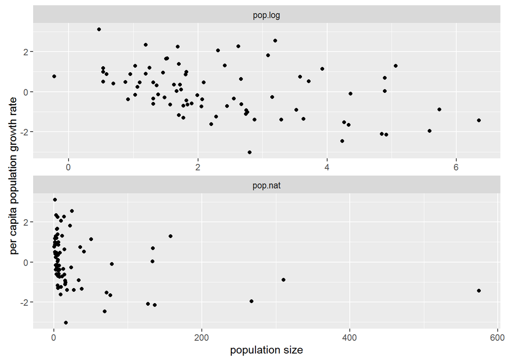

```r
thrip.ex2 = thrip  %>%
  mutate(pop.log=log(pop.nat)) %>%
  mutate(ratio=c(log(thrip[,"pop.nat"][2:nrow(thrip)]/thrip[,"pop.nat"][1:(nrow(thrip)-1)]), "NA")) %>%
  filter(ratio!="NA") %>%
  gather(key=variable, value=pop, -c(yr, month, time, ratio))

ggplot(data=thrip.ex2, aes(x=pop, y=as.numeric(ratio)), group=variable)+
  geom_point()+
  facet_wrap(~variable, nrow=2, scales="free")+
  #facet_grid(variable~., scales = "free")+ #this works
  #facet_grid(.~variable, scales = "free")+ #this is not working..
  xlab("population size")+
  ylab("per capita population growth rate")
```

```r
  # Question: why "acet_grid(variable~., scales = "free")" does not give me free x and y scale?
```

The thrip data only shows a slightly negative trend when the population size is log-transformed. Although there is also a negative relationship between per capita growth rate versus population size, it could be dominated by those measurements of large population size. This implies it might not be proper to fit the Ricker model to the thrip data as the error of the population size of thrip is probably not normally distributed.

# Exercise 3 and 4

```r
parus.ex3 = parus  %>%
  mutate(pop.log=log(pop.nat)) %>%
  mutate(ratio=c(log(parus[,"pop.nat"][2:nrow(parus)]/parus[,"pop.nat"][1:(nrow(parus)-1)]), "NA")) %>%
  filter(ratio!="NA")

parus.lm.ricker=lm(ratio~pop.nat, data=parus.ex3)
  summary(parus.lm.ricker)
```

```
##
## Call:
## lm(formula = ratio ~ pop.nat, data = parus.ex3)
##
## Residuals:
##     Min      1Q  Median      3Q     Max
## -0.4831 -0.1445 -0.0328  0.1754  0.5611
##
## Coefficients:
##              Estimate Std. Error t value Pr(>|t|)
## (Intercept)  0.851964   0.203216   4.192 0.000324 ***
## pop.nat     -0.004286   0.001002  -4.278 0.000260 ***
## ---
## Signif. codes:  0 '***' 0.001 '**' 0.01 '*' 0.05 '.' 0.1 ' ' 1
##
## Residual standard error: 0.2744 on 24 degrees of freedom
## Multiple R-squared:  0.4326, Adjusted R-squared:  0.409
## F-statistic:  18.3 on 1 and 24 DF,  p-value: 0.0002605
```

```r
  AIC(parus.lm.ricker)
```

```
## [1] 10.45834
```

```r
parus.r.ricker=parus.lm.ricker$coefficients[1]
parus.K.ricker=-(parus.lm.ricker$coefficients[1]/parus.lm.ricker$coefficients[2])

parus.lm.gomp=lm(ratio~pop.log, data=parus.ex3)
  summary(parus.lm.gomp)
```

```
##
## Call:
## lm(formula = ratio ~ pop.log, data = parus.ex3)
##
## Residuals:
##      Min       1Q   Median       3Q      Max
## -0.47007 -0.11711 -0.03817  0.17139  0.59720
##
## Coefficients:
##             Estimate Std. Error t value Pr(>|t|)
## (Intercept)   4.9198     1.0526   4.674 9.52e-05 ***
## pop.log      -0.9360     0.2006  -4.666 9.70e-05 ***
## ---
## Signif. codes:  0 '***' 0.001 '**' 0.01 '*' 0.05 '.' 0.1 ' ' 1
##
## Residual standard error: 0.2638 on 24 degrees of freedom
## Multiple R-squared:  0.4757, Adjusted R-squared:  0.4539
## F-statistic: 21.78 on 1 and 24 DF,  p-value: 9.697e-05
```

```r
  AIC(parus.lm.gomp)
```

```
## [1] 8.405904
```

```r
parus.r.gomp=-log(-parus.lm.gomp$coefficients[2])
parus.K.gomp=exp(parus.lm.gomp$coefficients[1]/-(parus.lm.gomp$coefficients[2]))
```

In the Parus data set, the carrying capacity of parus is estimated to be 198.7591214 by the Ricker model and 191.7407992 by the Gompertz model. The two estimates of carrying capacity are pretty similar. However, the two estimates of the intrinsic grwoth rate (0.8519642 by the Ricker model and 0.0661205 by the Gompertz model) in two model differ more than one order of magnitude. This is intriguing because the patters of the two relationships are so similar. From these results, I think the density dependency exists but the way to model density dependency largely affects the intrinsic growth rate and carrying capacity.

```r
thrip.ex3 = thrip  %>%
  mutate(pop.log=log(pop.nat)) %>%
  mutate(ratio=c(log(thrip[,"pop.nat"][2:nrow(thrip)]/thrip[,"pop.nat"][1:(nrow(thrip)-1)]), "NA")) %>%
  filter(ratio!="NA")

thrip.lm.ricker=lm(ratio~pop.nat, data=thrip.ex3)
  summary(thrip.lm.ricker)
```

```
##
## Call:
## lm(formula = ratio ~ pop.nat, data = thrip.ex3)
##
## Residuals:
##      Min       1Q   Median       3Q      Max
## -3.15319 -0.87882  0.09029  0.78246  2.91994
##
## Coefficients:
##              Estimate Std. Error t value Pr(>|t|)
## (Intercept)  0.200756   0.146142   1.374  0.17347
## pop.nat     -0.004489   0.001648  -2.725  0.00794 **
## ---
## Signif. codes:  0 '***' 0.001 '**' 0.01 '*' 0.05 '.' 0.1 ' ' 1
##
## Residual standard error: 1.2 on 78 degrees of freedom
## Multiple R-squared:  0.08691,    Adjusted R-squared:  0.0752
## F-statistic: 7.424 on 1 and 78 DF,  p-value: 0.007941
```

```r
  AIC(thrip.lm.ricker)
```

```
## [1] 260.1532
```

```r
thrip.r.ricker=thrip.lm.ricker$coefficients[1]
thrip.K.ricker=-(thrip.lm.ricker$coefficients[1]/thrip.lm.ricker$coefficients[2])

thrip.lm.gomp=lm(ratio~pop.log, data=thrip.ex3)
  summary(thrip.lm.gomp)
```

```
##
## Call:
## lm(formula = ratio ~ pop.log, data = thrip.ex3)
##
## Residuals:
##     Min      1Q  Median      3Q     Max
## -2.8967 -0.8548 -0.1965  0.7130  2.8199
##
## Coefficients:
##             Estimate Std. Error t value Pr(>|t|)
## (Intercept)  0.92217    0.24846   3.711 0.000385 ***
## pop.log     -0.37526    0.09107  -4.121 9.34e-05 ***
## ---
## Signif. codes:  0 '***' 0.001 '**' 0.01 '*' 0.05 '.' 0.1 ' ' 1
##
## Residual standard error: 1.138 on 78 degrees of freedom
## Multiple R-squared:  0.1788, Adjusted R-squared:  0.1682
## F-statistic: 16.98 on 1 and 78 DF,  p-value: 9.343e-05
```

```r
  AIC(thrip.lm.gomp)
```

```
## [1] 251.6712
```

```r
thrip.r.gomp=-log(-thrip.lm.gomp$coefficients[2])
thrip.K.gomp=exp(thrip.lm.gomp$coefficients[1]/-(thrip.lm.gomp$coefficients[2]))
```

In the Thrips data set, both the intrinsic growth rate (0.2007565 in the Ricker model vs 0.9801472 in the Gompertz model) and carrying capacity (44.719862 in the Ricker model vs 11.6748516 in the Gompertz model) estimated by both model are so different from each other. Although the Gompertz model perfomes slightly better than the Ricker model and returns a statistically significant slope, both model have poor explanation to the variation of per capita growth rate. Given this data set, density dependency probably does not exist, or at least not strong.

# Exercise 5

Extract the fitted values of each model using fitted or predict and plot these in the same manner you did above.

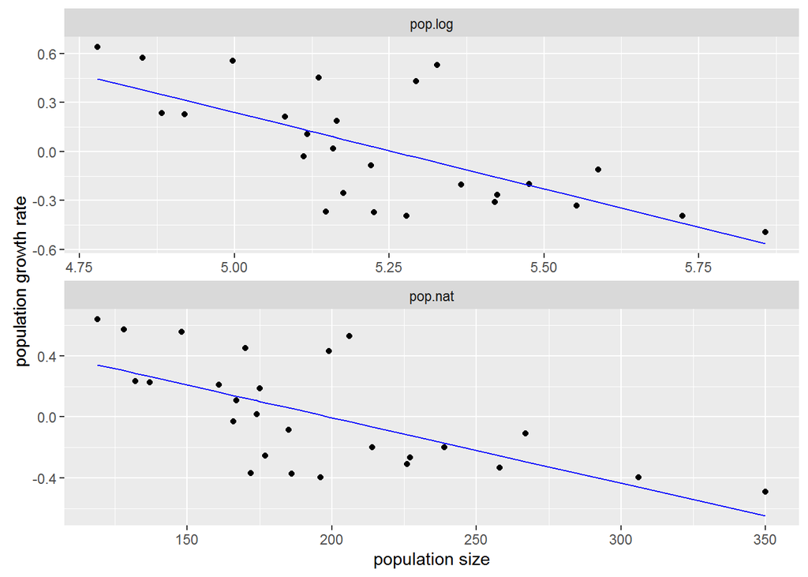

```r
parus.ex5 = parus.ex3  %>%
  gather(key=variable, value=pop, -c(yr, ratio)) %>%
  mutate(fit.ratio=c(predict(parus.lm.ricker), predict(parus.lm.gomp)))

ggplot(data=parus.ex5, group=variable)+
  geom_point(aes(x=pop, y=as.numeric(ratio)), col="black")+
  geom_line(aes(x=pop, y=as.numeric(fit.ratio)), col="blue")+
  facet_wrap(~variable, nrow=2, scales="free")+
  xlab("population size")+
  ylab("population growth rate")
```

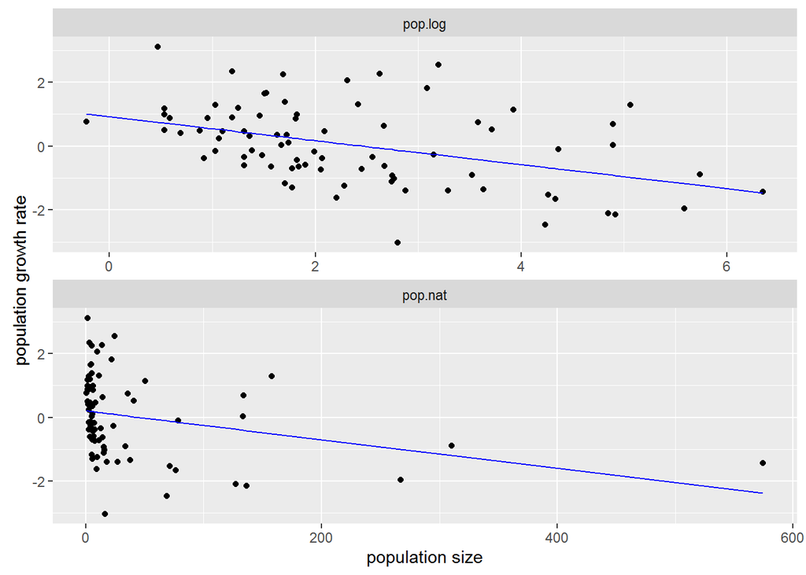

```r
thrip.ex5 = thrip.ex3  %>%
  gather(key=variable, value=pop, -c(yr, month, time, ratio)) %>%
  mutate(fit.ratio=c(predict(thrip.lm.ricker), predict(thrip.lm.gomp)))

ggplot(data=thrip.ex5, group=variable)+
  geom_point(aes(x=pop, y=as.numeric(ratio)), col="black")+
  geom_line(aes(x=pop, y=as.numeric(fit.ratio)), col="blue")+
  facet_wrap(~variable, nrow=2, scales="free")+
  xlab("population size")+
  ylab("population growth rate")
```

# Exercise 6

```r
summary(parus.lm.ricker)
```

```
##
## Call:
## lm(formula = ratio ~ pop.nat, data = parus.ex3)
##
## Residuals:
##     Min      1Q  Median      3Q     Max
## -0.4831 -0.1445 -0.0328  0.1754  0.5611
##
## Coefficients:
##              Estimate Std. Error t value Pr(>|t|)
## (Intercept)  0.851964   0.203216   4.192 0.000324 ***
## pop.nat     -0.004286   0.001002  -4.278 0.000260 ***
## ---
## Signif. codes:  0 '***' 0.001 '**' 0.01 '*' 0.05 '.' 0.1 ' ' 1
##
## Residual standard error: 0.2744 on 24 degrees of freedom
## Multiple R-squared:  0.4326, Adjusted R-squared:  0.409
## F-statistic:  18.3 on 1 and 24 DF,  p-value: 0.0002605
```

```r
anova(parus.lm.ricker)
```

```
## Analysis of Variance Table
##
## Response: ratio
##           Df Sum Sq Mean Sq F value    Pr(>F)
## pop.nat    1 1.3780 1.37797  18.301 0.0002605 ***
## Residuals 24 1.8071 0.07529
## ---
## Signif. codes:  0 '***' 0.001 '**' 0.01 '*' 0.05 '.' 0.1 ' ' 1
```

The $t-test$ performed on the slope estimation is identical to the $F-test$ performed on the model. This means including population size to explain the variation of per capita growth rate can reduce the residual sum of squares with a high probability (0.99974). This probabiilty is also the probability of observing the effects of population size on the per capita growth rate to be -0.004.

# Exercise 7

```r
parus.ex7=parus.ex5 %>%
  filter(variable=="pop.nat")

confint(parus.lm.ricker, level=0.95)
```

```
##                    2.5 %       97.5 %
## (Intercept)  0.432546551  1.271381946
## pop.nat     -0.006354373 -0.002218458
```

```r
confint(parus.lm.ricker, level=0.90)
```

```
##                      5 %         95 %
## (Intercept)  0.504285231  1.199643265
## pop.nat     -0.006000663 -0.002572169
```

```r
confint(parus.lm.ricker, level=0.80)
```

```
##                     10 %         90 %
## (Intercept)  0.584158590  1.119769907
## pop.nat     -0.005606843 -0.002965988
```

```r
confint(parus.lm.ricker, level=0.60)
```

```
##                     20 %         80 %
## (Intercept)  0.677837307  1.026091190
## pop.nat     -0.005144956 -0.003427875
```

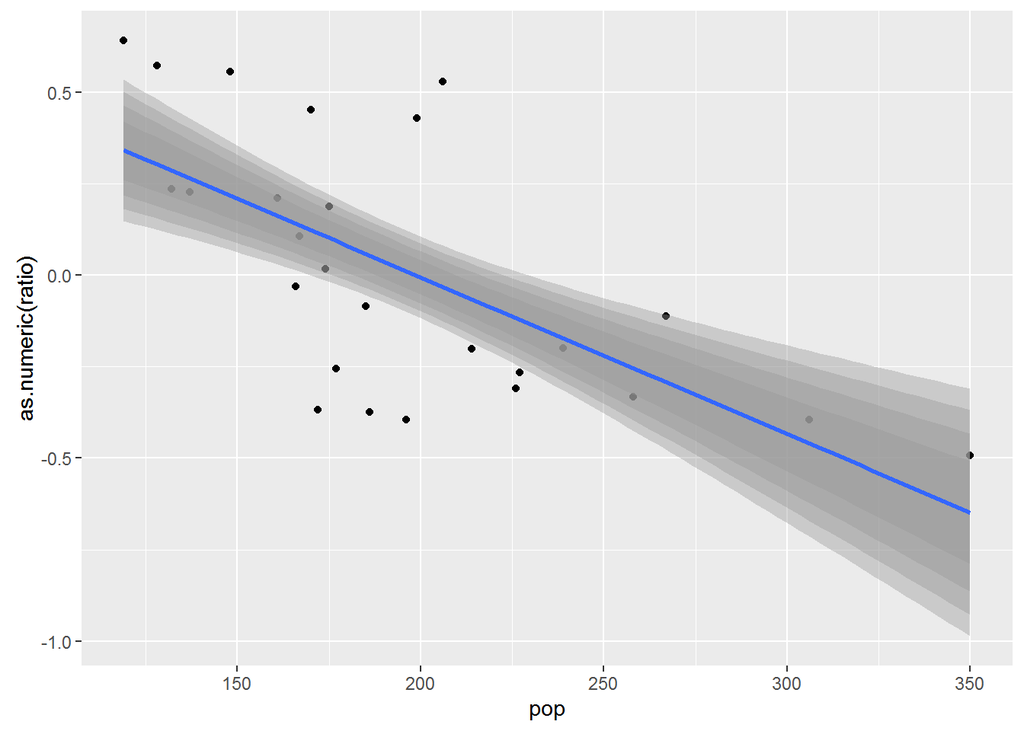

```r
ggplot(data=parus.ex7, aes(x=pop, y=as.numeric(ratio)))+
  geom_point(col="black")+
  geom_line(aes(x=pop, y=as.numeric(fit.ratio)), col="blue")+
  stat_smooth(method="lm", level=0.95)+
  stat_smooth(method="lm", level=0.90)+
  stat_smooth(method="lm", level=0.80)+
  stat_smooth(method="lm", level=0.60)
```

The shaded area (standard error of the linear model) gradually increase with the level of confidence interval specified. This is implies the increase of making Type I error when increasing the specified confidence interval.

# Exercise 8

Calculate the standard error of carrying capacity by the delta method.

```r
parus.lm.ricker=lm(ratio~pop.nat, data=parus.ex3)
summary(parus.lm.ricker)
```

```
##
## Call:
## lm(formula = ratio ~ pop.nat, data = parus.ex3)
##
## Residuals:
##     Min      1Q  Median      3Q     Max
## -0.4831 -0.1445 -0.0328  0.1754  0.5611
##
## Coefficients:
##              Estimate Std. Error t value Pr(>|t|)
## (Intercept)  0.851964   0.203216   4.192 0.000324 ***
## pop.nat     -0.004286   0.001002  -4.278 0.000260 ***
## ---
## Signif. codes:  0 '***' 0.001 '**' 0.01 '*' 0.05 '.' 0.1 ' ' 1
##
## Residual standard error: 0.2744 on 24 degrees of freedom
## Multiple R-squared:  0.4326, Adjusted R-squared:  0.409
## F-statistic:  18.3 on 1 and 24 DF,  p-value: 0.0002605
```

```r
parus.r.ricker=parus.lm.ricker$coefficients[1]
parus.K.ricker=-(parus.lm.ricker$coefficients[1]/parus.lm.ricker$coefficients[2])

#X = model.matrix(parus.lm.ricker) # design matrix
#B = solve(crossprod(X), crossprod(X, parus.ex3$ratio))
  # I can also calculate the Beta matrix by myself.
B = summary(parus.lm.ricker)$coefficients[,1]
vcovB = vcov(parus.lm.ricker) # variance-covariance matrix of the linear model (Ricker model)
  # The variance is the square of the standard error as there is only one beta (sample size=1)
  # I'm not entirely sure how the covariance is calculated...

fun2 = function(B){ # transformation function from coefficients to theta (carrying capacity in this case)
  theta2 = -(B[1]/B[2])
}

#install.packages("numDeriv")
# Here I installed a package to calculate the Jacobian matrix evaluated at the beta = beta hat, although I can calculate it by hand
library(numDeriv)

K.se = sqrt(jacobian(fun2, B) %*% vcovB %*% t(jacobian(fun2, B)))
K.se
```

```
##          [,1]
## [1,] 12.57648
```

```r
# The following package allows me to calculate the standard error of a parameter that is being transformed from the coefficients estimated in a model.
#install.packages("msm")
library(msm)
deltamethod(~ -(x1/x2), coef(parus.lm.ricker), vcov(parus.lm.ricker))
```

```
## [1] 12.57648
```

# Exercise 9

```r
parus.lm.ricker=lm(ratio~pop.nat, data=parus.ex3)
parus.ricker.AIC = AIC(parus.lm.ricker)

parus.lm.gomp=lm(ratio~pop.log, data=parus.ex3)
parus.gomp.AIC = AIC(parus.lm.gomp)

prob = exp((parus.gomp.AIC - parus.ricker.AIC)/2)
```

According to the AIC difference of the two models, the Ricker model, when comparing to the Gompertz model, is 0.3583599 times less likely to explain same amount of variance of the data.  
From the adjust $R^2$, we see that the Gompertz model explain about 4.49 % more variance than the Ricker model.

# Exercise 10

## Ex 10.1 Gompertz model and the Ricker model.

```r
thrip.ex3 = thrip  %>%
  mutate(pop.log=log(pop.nat)) %>%
  mutate(ratio=c(log(thrip[,"pop.nat"][2:nrow(thrip)]/thrip[,"pop.nat"][1:(nrow(thrip)-1)]), "NA")) %>%
  filter(ratio!="NA")
thrip.ex3[,"ratio"] = as.numeric(thrip.ex3[,"ratio"])

thrip.lm.ricker=lm(ratio~pop.nat, data=thrip.ex3)
thrip.ricker.AIC = AIC(thrip.lm.ricker)

thrip.lm.gomp=lm(ratio~pop.log, data=thrip.ex3)
thrip.gomp.AIC = AIC(thrip.lm.gomp)

prob = exp((thrip.gomp.AIC - thrip.ricker.AIC)/2)
```

Similarily, from the adjust $R^2$, we see that the Gompertz model explain about 9.3 % more variance than the Ricker model.

## Ex 10.2 Adjust $R^2$

Exploring the adjust $R^2$ value with different combination of independent variables in the Gompertz model.

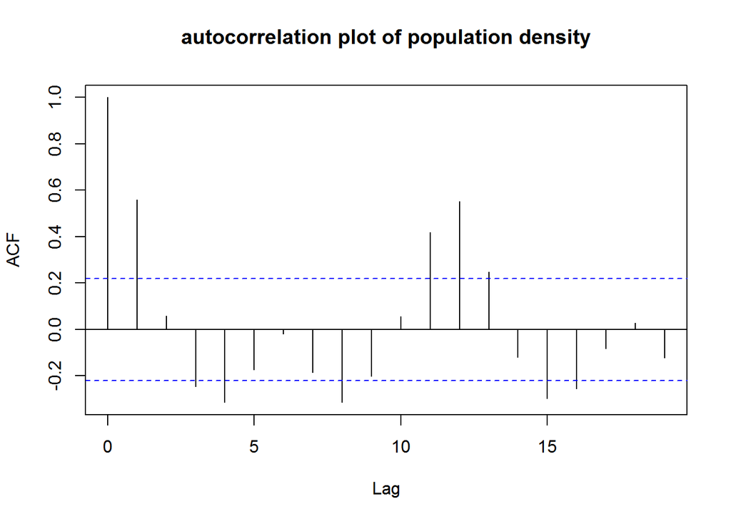

```r
acf(thrip.ex3$pop.log, main="autocorrelation plot of population density")
```

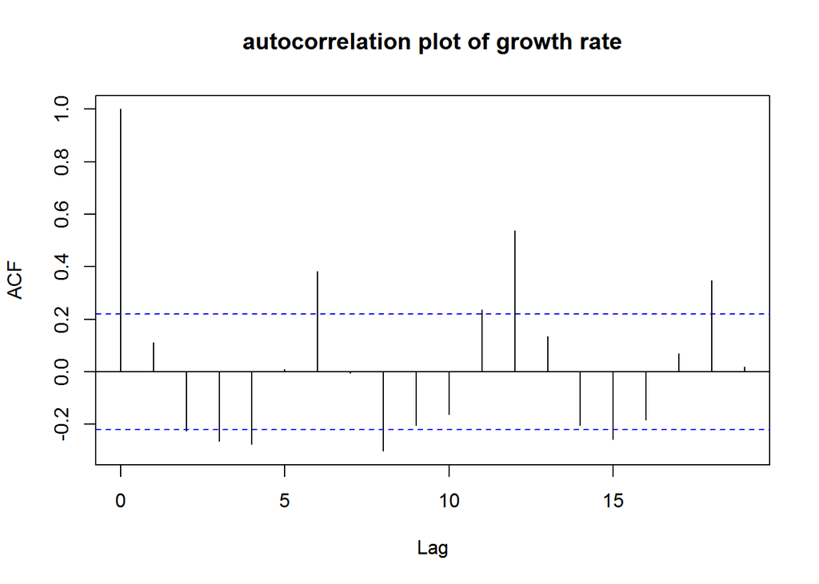

```r
acf(thrip.ex3$ratio, main="autocorrelation plot of growth rate")
```

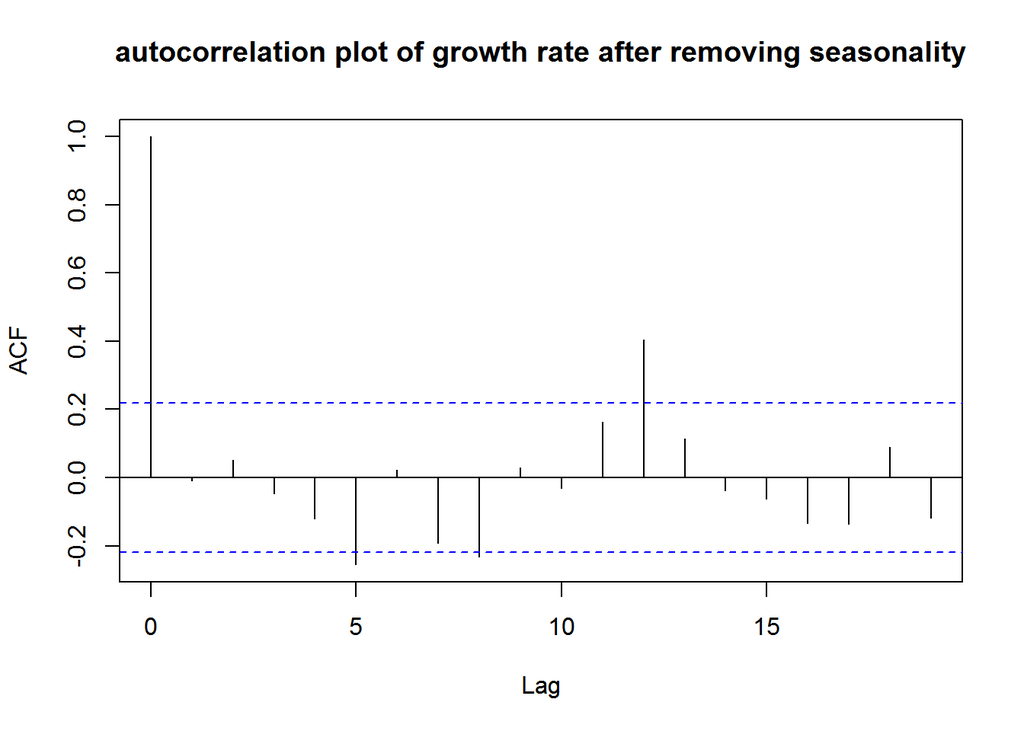

```r
acf(ts(residuals(arima(thrip.ex3$ratio, c(4, 0, 1)))), main="autocorrelation plot of growth rate after removing seasonality")
```

After removing the temporal autocorrelation (time lag=4), the ACF plot looks more clean.  
So I fit the Gompertz model with month ans it’s polynomial terms being the addition variables as well as fitting those independent varaible to the “deseasoned” dependent variable.

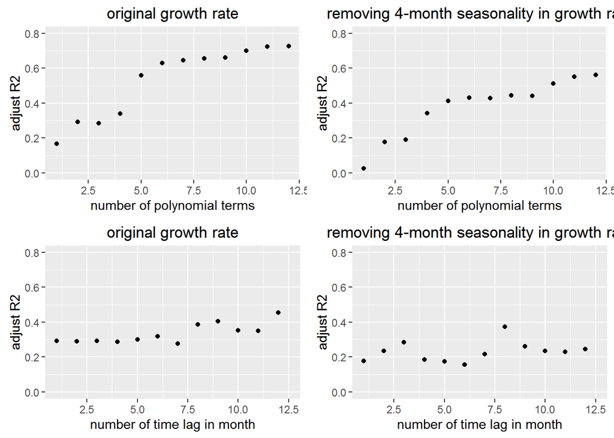

```r
thrip.ex10 = thrip.ex3 %>%
  mutate(ratio.dese4 = ts(residuals(arima(thrip.ex3$ratio, c(4, 0, 1)))))

adjR = c()
adjR.1 = c()
mod = lm(ratio~pop.log, data=thrip.ex10)
adjR = summary(mod)$adj.r.square
mod.1 = lm(ratio.dese4~pop.log, data=thrip.ex10)
adjR.1 = summary(mod.1)$adj.r.square

for (i in seq(1:11)) {
  mod = lm(ratio~pop.log + poly(month,i), data=thrip.ex10)
  mod.1 = lm(ratio.dese4~pop.log + poly(month,i), data=thrip.ex10)
  adjR = c(adjR, summary(mod)$adj.r.square)
  adjR.1 = c(adjR.1, summary(mod.1)$adj.r.square)
}

adjR.lag = c()
adjR.lag.1 = c()
mod.lag0 = lm(ratio~pop.log + month, data=thrip.ex10)
adjR.lag = summary(mod.lag0)$adj.r.square
mod.lag0.1 = lm(ratio.dese4~pop.log + month, data=thrip.ex10)
adjR.lag.1 = summary(mod.lag0.1)$adj.r.square


mon = ts(thrip.ex3$month)
for (i in seq(1:11)){
  mod.lag = lm(ratio~pop.log + month + lag(mon, i), data=thrip.ex10)
  adjR.lag = c(adjR.lag, summary(mod.lag)$adj.r.square)
  mod.lag.1 = lm(ratio.dese4~pop.log + month + lag(mon, i), data=thrip.ex10)
  adjR.lag.1 = c(adjR.lag.1, summary(mod.lag.1)$adj.r.square)
}

adjR.all = as.data.frame(cbind(adjR, adjR.1, adjR.lag, adjR.lag.1)) %>%
  gather(key=AdjR2, value=val, adjR, adjR.1, adjR.lag, adjR.lag.1) %>%
  mutate(num = rep(seq(1:12), 4))

p1 = ggplot(adjR.all[which(adjR.all[,"AdjR2"]=="adjR"),], aes(x=num, y=val))+
  geom_point()+
  xlim(1, 12)+
  ylim(0.0, 0.8)+
  labs(title="original growth rate", x="number of polynomial terms", y="adjust R2")
p2 = ggplot(adjR.all[which(adjR.all[,"AdjR2"]=="adjR.1"),], aes(x=num, y=val))+
  geom_point()+
  xlim(1, 12)+
  ylim(0.0, 0.8)+
  labs(title="removing 4-month seasonality in growth rate", x="number of polynomial terms", y="adjust R2")
#p12 = grid.arrange(p1, p2, ncol=2)

p3 = ggplot(adjR.all[which(adjR.all[,"AdjR2"]=="adjR.lag"),], aes(x=num, y=val))+
  geom_point()+
  xlim(1, 12.5)+
  ylim(0.0, 0.8)+
  labs(title="original growth rate", x="number of time lag in month", y="adjust R2")
p4 = ggplot(adjR.all[which(adjR.all[,"AdjR2"]=="adjR.lag.1"),], aes(x=num, y=val))+
  geom_point()+
  xlim(1, 12.5)+
  ylim(0.0, 0.8)+
  labs(title="removing 4-month seasonality in growth rate", x="number of time lag in month", y="adjust R2")
#p34 = grid.arrange(p3, p4, ncol=2)

pall = grid.arrange(p1, p2, p3, p4, ncol=2)
```

From the figure we see that, in terms of adjust $R^2$, the model with 11 polynomial terms of month being the independent variable and non deseasoned growth rate being the dependent variables is the one giving me highest adjust $R^2$ (0.727). However, having 11 polynomial terms is pretty hard to interpret.

# Exercise 11

## 11.a

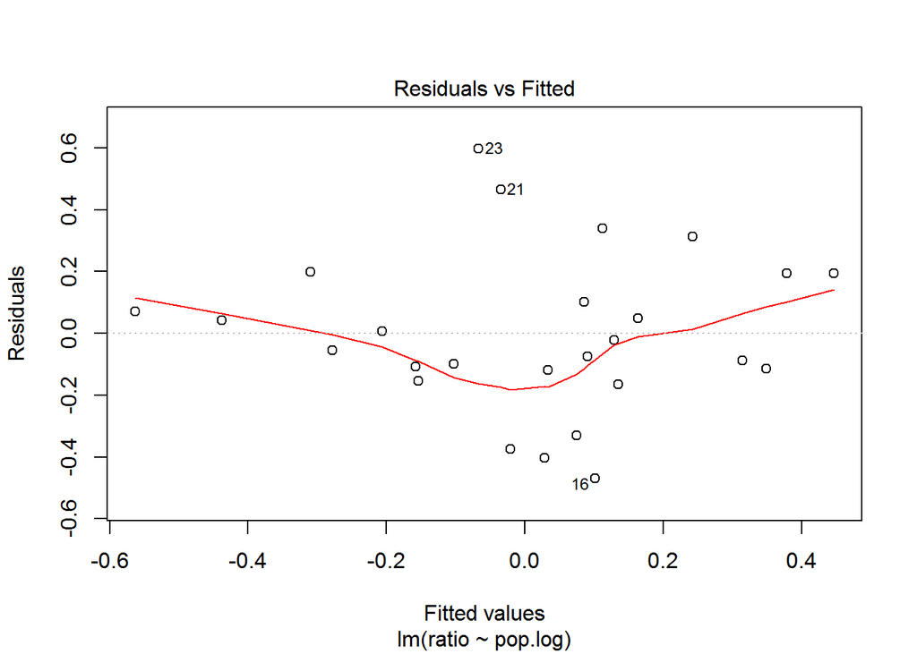

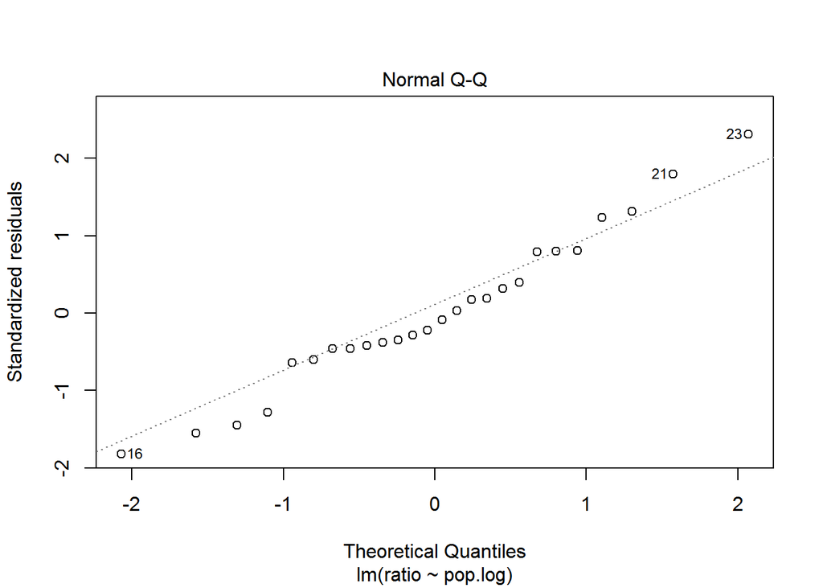

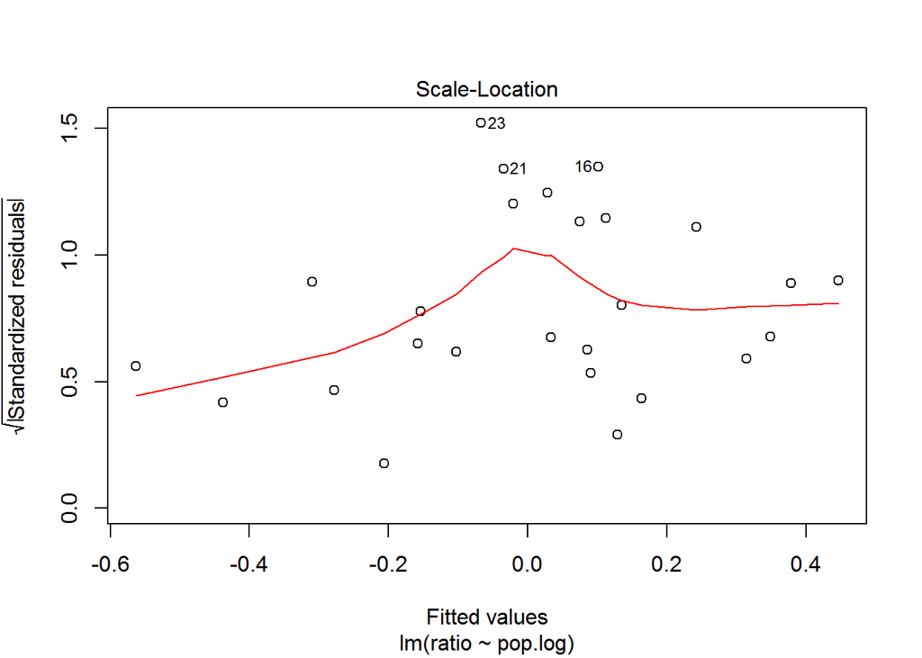

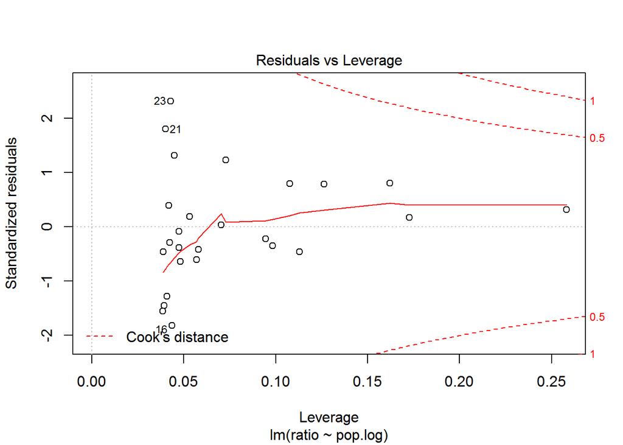

```r
plot(parus.lm.gomp)
```

```r
#bptest(parus.lm.gomp)
```

> The bptest is working when not in Rmd code, but when in Rmd code it generates a erroe message “Error in y - z$residuals :” But in the next exercise, this error does not appear.

## 11.b

```r
shapiro.test(residuals(parus.lm.gomp))
```

```
##
##  Shapiro-Wilk normality test
##
## data:  residuals(parus.lm.gomp)
## W = 0.97325, p-value = 0.7085
```

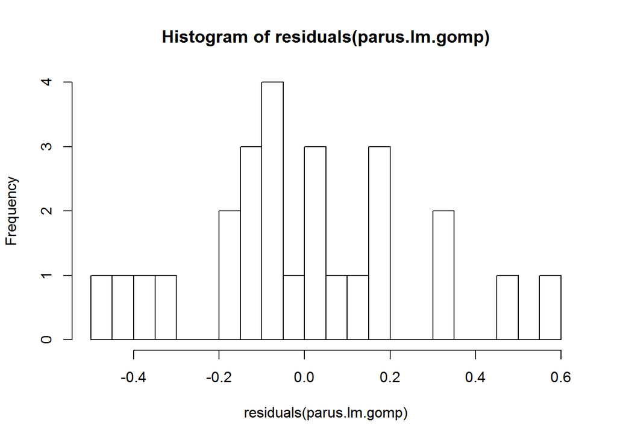

```r
hist(residuals(parus.lm.gomp), breaks=20)
```

The Shapiro-Wilk test also shows a nonsignificant result. This means the residuals are normally distributed. From the histogram of the residuals, we can see that the distribution really looks like a normal distribution.

## 11.c

From the fouth diagnostic plot (Residuals vs Leverage plot), point 23, 21 and 16 are the ones that have larger influences, but the leverage of ther three are rather small. The influences of the three could be fairly small.

## 11.d

```r
#dwtest(parus.lm.gomp)
```

> The dwtest is working when not in Rmd code, but when in Rmd code it generates a erroe message “Error in y - z$residuals :” But in the next exercise, this error does not appear.

## 11.e

```r
summary(parus.lm.gomp)
```

```
##
## Call:
## lm(formula = ratio ~ pop.log, data = parus.ex3)
##
## Residuals:
##      Min       1Q   Median       3Q      Max
## -0.47007 -0.11711 -0.03817  0.17139  0.59720
##
## Coefficients:
##             Estimate Std. Error t value Pr(>|t|)
## (Intercept)   4.9198     1.0526   4.674 9.52e-05 ***
## pop.log      -0.9360     0.2006  -4.666 9.70e-05 ***
## ---
## Signif. codes:  0 '***' 0.001 '**' 0.01 '*' 0.05 '.' 0.1 ' ' 1
##
## Residual standard error: 0.2638 on 24 degrees of freedom
## Multiple R-squared:  0.4757, Adjusted R-squared:  0.4539
## F-statistic: 21.78 on 1 and 24 DF,  p-value: 9.697e-05
```

```r
library(msm)
parus.r.se = deltamethod(~ -log(-x2), coef(parus.lm.gomp), vcov(parus.lm.gomp))
parus.K.se = deltamethod(~ exp(x1/-(x2)), coef(parus.lm.gomp), vcov(parus.lm.gomp))
```

In the Gompertz model, the carrying capacity is estimated to be 191.741 with standard error about 10.614. This number is biologically reasonable. However, the intrinsic growth rate is the Gompertz model is estimated to be 0.066 with standard error about 0.214. The standard error of intrinsic growth rate is large so that the confidence interval of intrinsic growth rate overlaps 0. This suggests that the intrinsic growth rate estimated in the Gompertz model is not significantly different from 0, which is biologically not feasible.

# Exercise 12

## 12.a

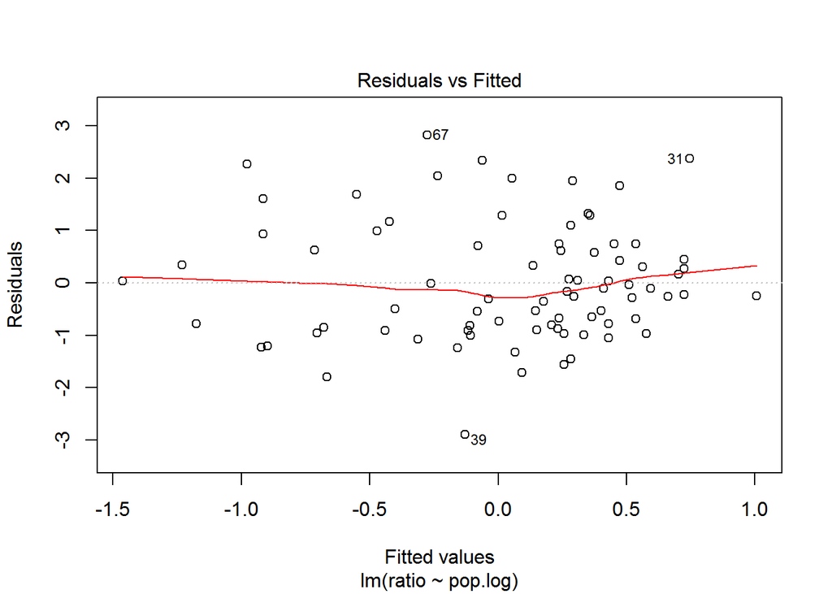

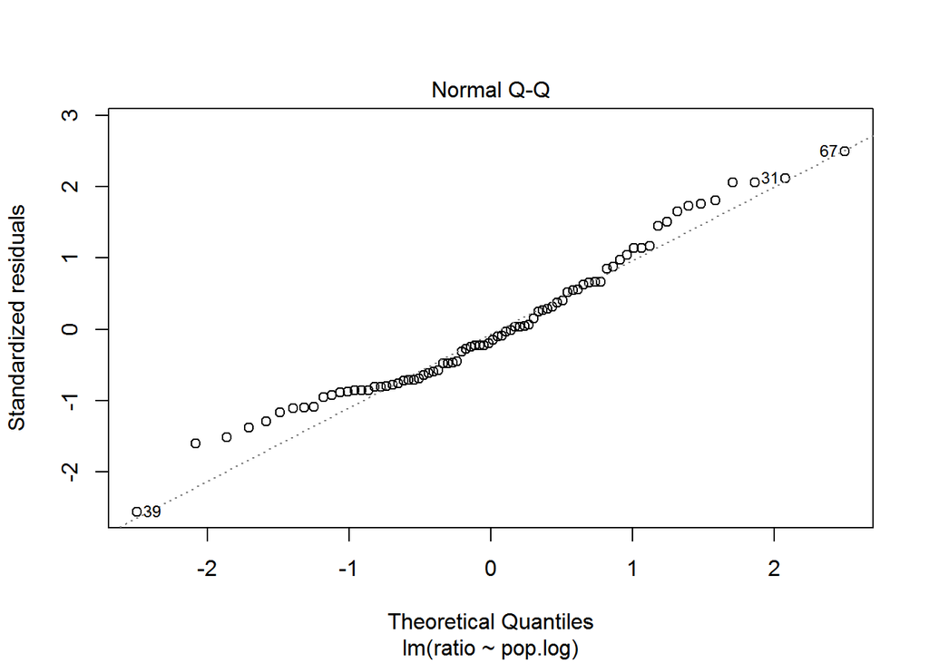

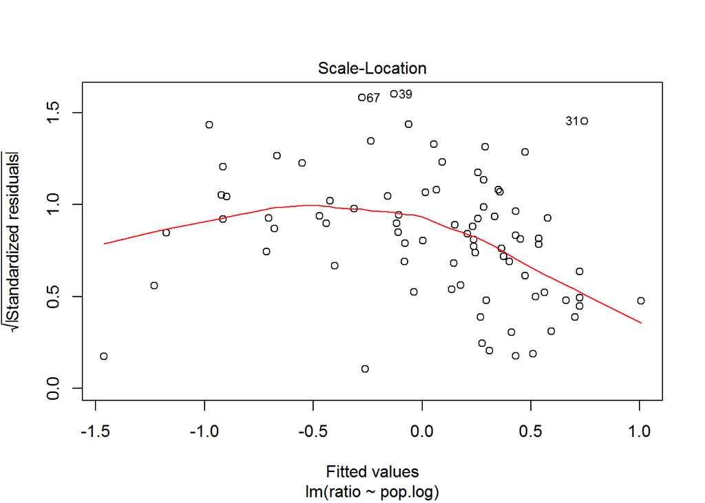

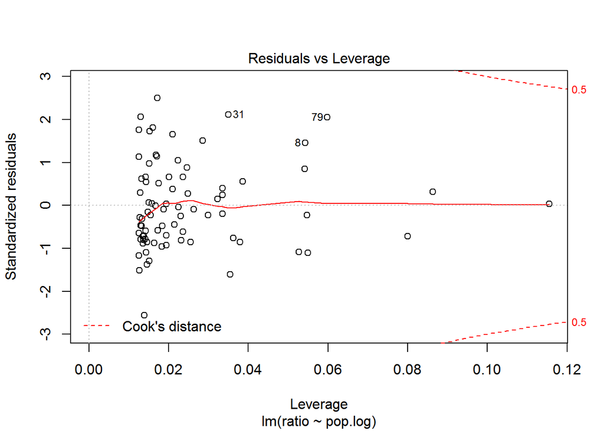

```r
plot(thrip.lm.gomp)
```

```r
bptest(thrip.lm.gomp)
```

```
##
##  studentized Breusch-Pagan test
##
## data:  thrip.lm.gomp
## BP = 2.8015, df = 1, p-value = 0.09418
```

From the first diagnostic plot (residuals on the y axis against fitted values on the x), we see that residuals are more aggregated when fitted values are large. The normal qqnorm plot (the second diagnostic plot), however does not show a non normally distributed pattern to me. This suggests that there could exist a structure in the residuals.

## 12.b

```r
shapiro.test(residuals(thrip.lm.gomp))
```

```
##
##  Shapiro-Wilk normality test
##
## data:  residuals(thrip.lm.gomp)
## W = 0.96839, p-value = 0.04483
```

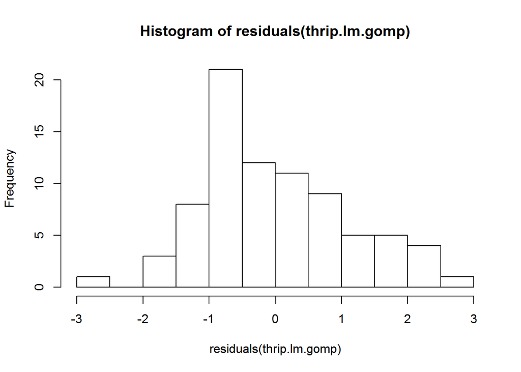

```r
hist(residuals(thrip.lm.gomp), breaks=20)
```

The Shapiro-Wilk test also shows a barely significant result. This means the residuals are not normally distributed, althought the histogram does look like a normal distribution.

> Here I have a question. Should we trust the statistical test or the shape of the histogram when judging if a variable follows a normal distribution?

## 12.d

```r
dwtest(thrip.lm.gomp)
```

```
##
##  Durbin-Watson test
##
## data:  thrip.lm.gomp
## DW = 1.4897, p-value = 0.008394
## alternative hypothesis: true autocorrelation is greater than 0
```

## 12.e

```r
summary(thrip.lm.gomp)
```

```
##
## Call:
## lm(formula = ratio ~ pop.log, data = thrip.ex3)
##
## Residuals:
##     Min      1Q  Median      3Q     Max
## -2.8967 -0.8548 -0.1965  0.7130  2.8199
##
## Coefficients:
##             Estimate Std. Error t value Pr(>|t|)
## (Intercept)  0.92217    0.24846   3.711 0.000385 ***
## pop.log     -0.37526    0.09107  -4.121 9.34e-05 ***
## ---
## Signif. codes:  0 '***' 0.001 '**' 0.01 '*' 0.05 '.' 0.1 ' ' 1
##
## Residual standard error: 1.138 on 78 degrees of freedom
## Multiple R-squared:  0.1788, Adjusted R-squared:  0.1682
## F-statistic: 16.98 on 1 and 78 DF,  p-value: 9.343e-05
```

```r
library(msm)
thrip.r.se = deltamethod(~ -log(-x2), coef(thrip.lm.gomp), vcov(thrip.lm.gomp))
thrip.K.se = deltamethod(~ exp(x1/-(x2)), coef(thrip.lm.gomp), vcov(thrip.lm.gomp))
```

# Exercise 13

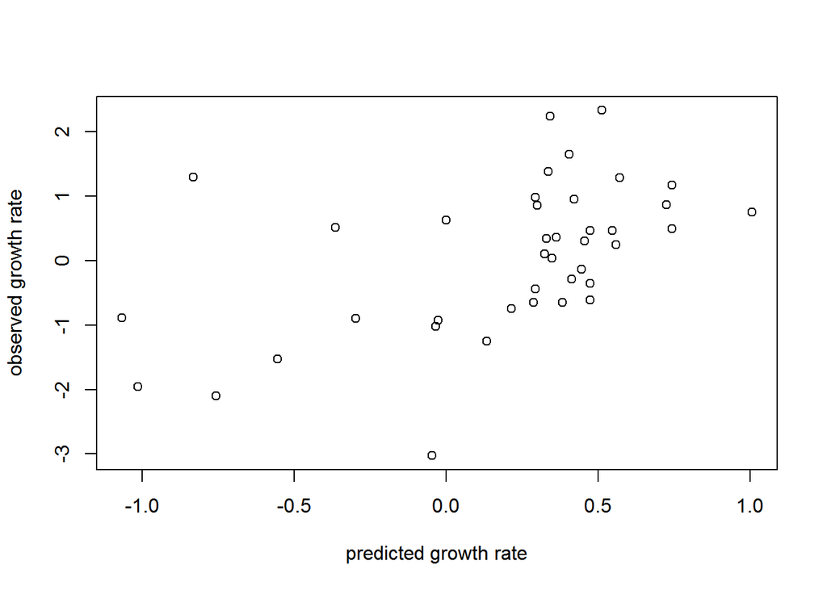

```r
set.seed(543)
train.id = sample(seq(1: nrow(thrip.ex3)), nrow(thrip.ex3)/2, replace=FALSE)
train.mod = lm(ratio~pop.log, data=thrip.ex3[train.id,])
y.pred = predict(train.mod, newdata=thrip.ex3[-train.id,])

plot(thrip.ex3[-train.id,"ratio"]~y.pred, xlab="predicted growth rate", ylab="observed growth rate")
```

```r
summary(lm(y.pred~thrip.ex3[-train.id,"ratio"]))
```

```
##
## Call:
## lm(formula = y.pred ~ thrip.ex3[-train.id, "ratio"])
##
## Residuals:
##     Min      1Q  Median      3Q     Max
## -1.2911 -0.1480  0.1148  0.2881  0.6611
##
## Coefficients:
##                               Estimate Std. Error t value Pr(>|t|)
## (Intercept)                    0.18612    0.06675   2.788 0.008228 **
## thrip.ex3[-train.id, "ratio"]  0.21119    0.05828   3.624 0.000847 ***
## ---
## Signif. codes:  0 '***' 0.001 '**' 0.01 '*' 0.05 '.' 0.1 ' ' 1
##
## Residual standard error: 0.4216 on 38 degrees of freedom
## Multiple R-squared:  0.2568, Adjusted R-squared:  0.2373
## F-statistic: 13.13 on 1 and 38 DF,  p-value: 0.0008466
```

Here I randomly chose Using half of the data to estimate carrying capacity (K) and intrinsic growth rate (r) and then use these estimated K and r to predict growth rate in the other half of the data. When plotted the observed growth rate against the predicted growth rate, the two are not matching with each other well. Predicted growth rates only explain 23.73% of the variance of observed growth rate. This is not much better than fitting the whole data set (adjust $R^2$ is 0.168). I suspect this is due to the fact that this linear model *per se* does not capture the 4-month seasonality.

# Exercise 14